# SENESCU_B_FinalProject

Ben Senescu

November 30, 2018

Load in all the packages used in the project

```r
library(httr)
library(XML)
library(RSQLite)
library(plyr)
library(jsonlite)
library(rvest)
library(RSelenium)
library(Amelia)
library(httr)
library(XML)
library(RSQLite)
library(RSelenium)
library(stringr)
library(sqldf)
```

```r
library(ggplot2)
library(ROCR)
library(forecast)
```

Get a vector of the ticker symbols for all stocks trading on the NASDAQ from the IEX Trading API.

```r
#call API
symbol_request <- GET("https://api.iextrading.com/1.0/ref-data/symbols")
#check that request was successful
#http_status(api_request)

#get a list of all of the info associated with the symbols
symbol_list <- content(symbol_request, "parsed")

#convert the list into a data frame
symbol_df <- data.frame(matrix(unlist(symbol_list), nrow= length(symbol_list), byrow=T),stringsAsFactors=FALSE)

#get a vector of all of the symbols
allSymbols <- symbol_df$X1

head(allSymbols)
```

```
## [1] "A"    "AA"   "AAAU" "AABA" "AAC"  "AADR"
```

Create a data frame containing the symbol of the stock and what industry it is in.

```r
sector_df <- data.frame(Symbol=character(), Sector=character())

#find the sector for each symbol
for(symbol in allSymbols) {
  sector <- content(GET(paste("https://api.iextrading.com/1.0/stock/",
                                 symbol, "/company?filter=sector", sep = "")), "parsed")
  #if null, change it to an NA for easier processing
  if(is.null(sector$sector)) {
    sector_df <- rbind(sector_df, data.frame(symbol, sector = NA))
  } else {
    #add the new symbol and sector to the growing df
    sector_df <- rbind(sector_df, data.frame(symbol, sector))
  }
}
head(sector_df)
```

```
##   symbol             sector
## 1      A         Healthcare
## 2     AA    Basic Materials
## 3   AAAU
## 4   AABA Financial Services
## 5    AAC         Healthcare
## 6   AADR
```

I chose to remove all empty industry values from the set because industry is the way I plan to group stocks.

```r
#check how common NA's are in the dataframe
sapply(sector_df, function(x) sum(is.na(x)))
```

```
## symbol sector
##      0    156
```

```r
#change empty sector values to NA
sector_df$sector[sector_df$sector == ""] <- NA

#remove NA values
sectorFull_df <- na.omit(sector_df)
rownames(sectorFull_df) <- 1:nrow(sectorFull_df)

#check that all NA values have been removed
sapply(sectorFull_df, function(x) sum(is.na(x)))
```

```
## symbol sector
##      0      0
```

```r
#take a look at data to confirm
head(sectorFull_df)
```

```
##   symbol             sector
## 1      A         Healthcare
## 2     AA    Basic Materials
## 3   AABA Financial Services
## 4    AAC         Healthcare
## 5    AAL        Industrials
## 6   AAMC Financial Services
```

Write the sector df to a csv.

```r
write.csv(sectorFull_df, "sector_df.csv")
```

Create a database for stock information.

```r
dbOpen <- sqldf("attach Stock_db as new")
Stock_db <- dbConnect(RSQLite::SQLite(), "Stock_db")
```

Create a table to store the sector df information.

```r
dbfill <- dbWriteTable(Stock_db, "sector_table", read.csv("sector_df.csv"), overwrite = TRUE, row.names = FALSE, header = TRUE)
```

Take a look at what industries are most common among the data set.

```r
dbGetQuery(Stock_db, "SELECT sector, COUNT(*) FROM sector_table
           GROUP BY sector")
```

```
##                    sector COUNT(*)
## 1         Basic Materials      303
## 2  Communication Services      103
## 3       Consumer Cyclical      598
## 4      Consumer Defensive      217
## 5                  Energy      327
## 6      Financial Services     1535
## 7              Healthcare      863
## 8             Industrials      757
## 9             Real Estate      450
## 10             Technology      734
## 11              Utilities      142
```

This function takes in an industry of the users choice and returns the ticker symbols of all companies in that industry.

```r
filterSymbolsByIndustry <- function(Industry) {
  return(dbGetQuery(Stock_db, paste("SELECT symbol FROM sector_table WHERE sector = '", Industry, "'", sep = "")))
}

techSymbols <- filterSymbolsByIndustry("Technology")
healthcareSymbols <- filterSymbolsByIndustry("Healthcare")
financialSymbols <- filterSymbolsByIndustry("Financial Services")
```

Take the unformatted data frame that fromJSON creates and reformat to a tidy df.

```r
makeDf <- function(df, symbol) {
  #ensure that there are not null values which cause problems in construcitng dataframes
  if(nrow(df) == 4) {
    finalDf <- data.frame(symbol = symbol, q1EPS = df[4, 'actualEPS'], q2EPS = df[3, 'actualEPS'],
                        q3EPS = df[2, 'actualEPS'], q4EPS = df[1, 'actualEPS'],
                        q1EPSReportDate = df[4, 'EPSReportDate'], q2EPSReportDate = df[3, 'EPSReportDate'],
                        q3EPSReportDate = df[2, 'EPSReportDate'], q4EPSReportDate = df[1, 'EPSReportDate'])
  } else {
    finalDf <- data.frame()
  }
  return(finalDf)
}
```

Pull the earnings information from the API and create a dataframe representing it.

```r
makeEarningsDf <- function(Symbols) {
  url <- paste("https://api.iextrading.com/1.0/stock/",
               Symbols[1], "/earnings?filter=actualEPS,EPSReportDate", sep = "")

  earnings_df <- as.data.frame(fromJSON(content(GET(url), "text"))[["earnings"]])
  earnings_df <- makeDf(earnings_df, Symbols[1])
  for(symbol in Symbols[2:length(Symbols)]) {
    url <- paste("https://api.iextrading.com/1.0/stock/",
               symbol, "/earnings?filter=actualEPS,EPSReportDate", sep = "")

    df <- as.data.frame(fromJSON(content(GET(url), "text"))[["earnings"]])

    earnings_df <- rbind(earnings_df, makeDf(df, symbol))
  }
  return(earnings_df)
}

techEarnings <- makeEarningsDf(techSymbols$symbol)
healthcareEarnings <- makeEarningsDf(healthcareSymbols$symbol)
financialEarnings <- makeEarningsDf(financialSymbols$symbol)
```

Check the structure of techEarnings.

```r
head(techEarnings)
```

```
##   symbol q1EPS q2EPS q3EPS q4EPS q1EPSReportDate q2EPSReportDate
## 1   AAOI  0.79  0.17  0.53    NA      2018-02-21      2018-05-08
## 2   AAPL  3.89  2.73  2.34  2.91      2018-02-01      2018-05-01
## 3   ABIL -0.12    NA -1.23    NA      2017-12-27      2018-05-15
## 4   ACIA  0.12 -0.03 -0.08  0.23      2018-02-22      2018-05-03
## 5   ACIW  0.64 -0.17 -0.13  0.22      2018-02-22      2018-05-10
## 6   ACLS  0.47  0.41  0.43  0.22      2018-02-06      2018-05-02
##   q3EPSReportDate q4EPSReportDate
## 1      2018-08-07      2018-11-07
## 2      2018-07-31      2018-11-01
## 3      2018-07-11      2018-10-03
## 4      2018-08-02      2018-11-01
## 5      2018-08-02      2018-11-08
## 6      2018-08-02      2018-11-01
```

Check if there are NA values.

```r
sapply(techEarnings, function(x) sum(is.na(x)))
```

```
##          symbol           q1EPS           q2EPS           q3EPS
##               0              50              29              22
##           q4EPS q1EPSReportDate q2EPSReportDate q3EPSReportDate
##              34               0               0               0
## q4EPSReportDate
##               0
```

```r
sapply(healthcareEarnings, function(x) sum(is.na(x)))
```

```
##          symbol           q1EPS           q2EPS           q3EPS
##               0              67              45              39
##           q4EPS q1EPSReportDate q2EPSReportDate q3EPSReportDate
##              32               0               0               0
## q4EPSReportDate
##               0
```

```r
sapply(financialEarnings, function(x) sum(is.na(x)))
```

```
##          symbol           q1EPS           q2EPS           q3EPS
##               0              52              46              34
##           q4EPS q1EPSReportDate q2EPSReportDate q3EPSReportDate
##              39               0               0               0
## q4EPSReportDate
##               0
```

Remove NA EPS reports because these are what I will be using as predictors for one of my models.

```r
tidyTechEarnings <- techEarnings[complete.cases(techEarnings),]
tidyHealthcareEarnings <- healthcareEarnings[complete.cases(healthcareEarnings),]
tidyFinancialEarnings <- financialEarnings[complete.cases(financialEarnings),]
head(tidyTechEarnings)
```

```
##   symbol q1EPS q2EPS q3EPS q4EPS q1EPSReportDate q2EPSReportDate
## 2   AAPL  3.89  2.73  2.34  2.91      2018-02-01      2018-05-01
## 4   ACIA  0.12 -0.03 -0.08  0.23      2018-02-22      2018-05-03
## 5   ACIW  0.64 -0.17 -0.13  0.22      2018-02-22      2018-05-10
## 6   ACLS  0.47  0.41  0.43  0.22      2018-02-06      2018-05-02
## 7   ACMR  0.23 -0.04  0.19  0.21      2018-03-05      2018-05-08
## 8    ACN  1.79  1.58  1.79  1.58      2017-12-21      2018-03-22
##   q3EPSReportDate q4EPSReportDate
## 2      2018-07-31      2018-11-01
## 4      2018-08-02      2018-11-01
## 5      2018-08-02      2018-11-08
## 6      2018-08-02      2018-11-01
## 7      2018-08-07      2018-11-07
## 8      2018-06-28      2018-09-27
```

```r
head(tidyHealthcareEarnings)
```

```
##   symbol q1EPS q2EPS q3EPS q4EPS q1EPSReportDate q2EPSReportDate
## 1      A  0.66  0.65  0.67  0.81      2018-02-14      2018-05-14
## 2    AAC  0.10  0.13  0.09 -0.08      2018-02-21      2018-05-02
## 3   ABBV  1.48  1.87  2.00  2.14      2018-01-26      2018-04-26
## 4    ABC  1.55  1.94  1.54  1.45      2018-02-06      2018-05-02
## 5   ABEO -0.19 -0.18 -0.25 -0.34      2018-03-16      2018-05-11
## 6   ABIO -0.34 -0.20 -0.15 -0.11      2018-03-22      2018-05-08
##   q3EPSReportDate q4EPSReportDate
## 1      2018-08-14      2018-11-19
## 2      2018-08-01      2018-11-06
## 3      2018-07-27      2018-11-02
## 4      2018-08-02      2018-11-06
## 5      2018-08-09      2018-11-09
## 6      2018-08-09      2018-11-14
```

```r
head(tidyFinancialEarnings)
```

```
##   symbol q1EPS q2EPS q3EPS q4EPS q1EPSReportDate q2EPSReportDate
## 2   AAMC -1.15 -0.92 -0.69 -0.75      2018-03-01      2018-05-08
## 4     AB  0.84  0.73  0.62  0.69      2018-02-13      2018-04-26
## 5   ABCB  0.63  0.73  0.74  0.91      2018-01-26      2018-04-20
## 6   ABDC  0.28  0.27  0.25  0.22      2018-03-14      2018-05-07
## 7   ABTX  0.51  0.57  0.68  0.65      2018-01-25      2018-04-26
## 8     AC  0.67 -0.95  0.51 -0.32      2018-02-21      2018-05-08
##   q3EPSReportDate q4EPSReportDate
## 2      2018-08-09      2018-11-07
## 4      2018-07-26      2018-10-24
## 5      2018-07-27      2018-10-19
## 6      2018-08-06      2018-11-05
## 7      2018-07-26      2018-10-25
## 8      2018-08-07      2018-11-06
```

Remove EPS Outliers.

```r
findOutliers <- function(vector) {
  zscores <- scale(vector)
  indicies <- match(zscores[abs(zscores) > 3], zscores)
  return(vector[indicies])
}

q1EPSOutliers <- findOutliers(tidyTechEarnings$q1EPS)
q2EPSOutliers <- findOutliers(tidyTechEarnings$q2EPS)
q3EPSOutliers <- findOutliers(tidyTechEarnings$q3EPS)
q4EPSOutliers <- findOutliers(tidyTechEarnings$q4EPS)

print(paste("Q1EPS Outliers:", paste(q1EPSOutliers, collapse = ",")))
```

```
## [1] "Q1EPS Outliers: 4.71,9.7,9.7,5.18,4.34,19.05,4.3"
```

```r
print(paste("Q2EPS Outliers:", paste(q2EPSOutliers, collapse = ",")))
```

```
## [1] "Q2EPS Outliers: 4.38,-2.91,3.37,9.93,9.93,4.56,4.79,3.36"
```

```r
print(paste("Q3EPS Outliers:", paste(q3EPSOutliers, collapse = ",")))
```

```
## [1] "Q3EPS Outliers: 4.38,11.75,11.75,5.31,3.41"
```

```r
print(paste("Q4EPS Outliers:", paste(q4EPSOutliers, collapse = ",")))
```

```
## [1] "Q4EPS Outliers: 5.14,13.06,13.06,3.5"
```

```r
tidyTechEarnings <- tidyTechEarnings[-which(tidyTechEarnings$q3EPS %in% q3EPSOutliers),]
tidyTechEarnings <- tidyTechEarnings[-which(tidyTechEarnings$q1EPS %in% q1EPSOutliers),]
tidyTechEarnings <- tidyTechEarnings[-which(tidyTechEarnings$q2EPS %in% q2EPSOutliers),]
tidyTechEarnings <- tidyTechEarnings[-which(tidyTechEarnings$q4EPS %in% q4EPSOutliers),]
```

Visualize the EPS for all quarters for the technology sector. We can see that the distribution is typically the same throughout the year. Most companies tend to break even or or earn up to $2 per share.

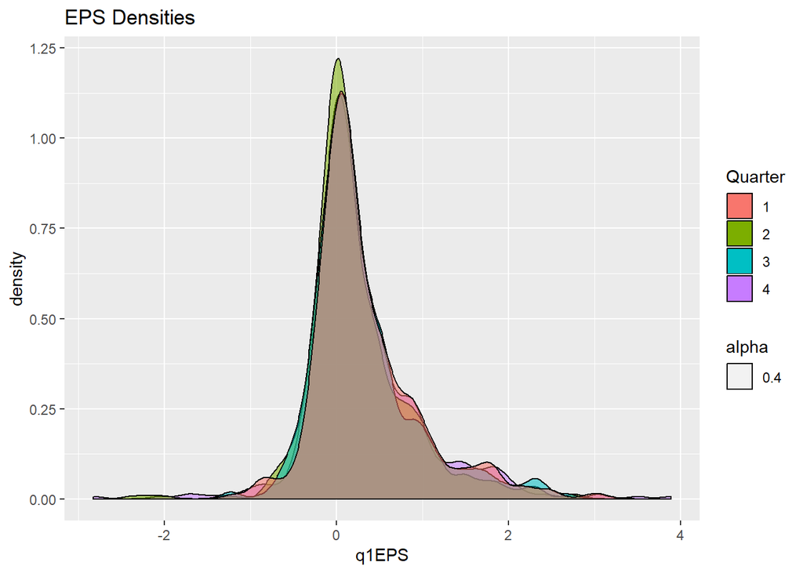

```r
ggplot(tidyTechEarnings) +
  geom_density(aes(x = q1EPS, fill="lightred", alpha = .4)) +
  geom_density(aes(x = q2EPS, fill="lightgreen", alpha = .4)) +
  geom_density(aes(x = q3EPS, fill="lightpurple", alpha = .4)) +
  geom_density(aes(x = q4EPS, fill="lightblue", alpha = .4)) +
  scale_fill_discrete(name='Quarter',labels=c("1", "2", "3", "4")) +
  ggtitle("EPS Densities")
```

```r
allEarnings <- rbind(tidyTechEarnings, tidyHealthcareEarnings, tidyHealthcareEarnings)
```

Create training and test sets for the data.

```r
createTrainingAndTestSets <- function(df){
  totalRows <- nrow(df)
  trainingNums <- sample(totalRows, totalRows * .7, replace = FALSE)
  training_df <- df[trainingNums,]
  testNums <- setdiff(c(1:totalRows), trainingNums)
  test_df <- df[testNums,]
  rownames(training_df) <- 1:nrow(training_df)
  rownames(test_df) <- 1:nrow(test_df)
  return(list(training_df, test_df))
}
```

Create a new dataframe with an extra column representing and EPS increase or decrease.

```r
logAllEarnings <- allEarnings

#create a new column representing if the eps increased or decreased
logAllEarnings$EPSIncrease <- 0

#if earnings in q4 are greater than in q3, change EPSIncrease to 1
logAllEarnings$EPSIncrease[which(logAllEarnings$q4EPS > logAllEarnings$q3EPS)] <- 1

#create trainging and set sets
sets <- createTrainingAndTestSets(logAllEarnings)
trainingLogAllEarnings <- sets[[1]]
testLogAllEarnings <- sets[[2]]
head(trainingLogAllEarnings)
```

```
##   symbol q1EPS q2EPS q3EPS q4EPS q1EPSReportDate q2EPSReportDate
## 1   OHRP -0.08 -0.07 -0.05 -0.01      2017-12-15      2018-02-14
## 2   SENS -0.12 -0.16 -0.16 -0.14      2018-03-13      2018-05-10
## 3     CO  0.09  0.04  0.09  0.08      2018-02-26      2018-06-26
## 4   OBSV -0.48 -0.54 -0.49 -0.42      2018-03-09      2018-05-16
## 5   APPF  0.07  0.12  0.21  0.16      2018-02-26      2018-04-30
## 6   MDWD -0.08 -0.17 -0.15 -0.11      2018-03-19      2018-05-10
##   q3EPSReportDate q4EPSReportDate EPSIncrease
## 1      2018-05-15      2018-08-14           1
## 2      2018-08-08      2018-11-08           1
## 3      2018-08-23      2018-11-27           0
## 4      2018-08-08      2018-11-08           1
## 5      2018-07-30      2018-10-29           0
## 6      2018-08-07      2018-11-13           1
```

```r
head(testLogAllEarnings)
```

```
##   symbol q1EPS q2EPS q3EPS q4EPS q1EPSReportDate q2EPSReportDate
## 1   AAPL  3.89  2.73  2.34  2.91      2018-02-01      2018-05-01
## 2   ACIW  0.64 -0.17 -0.13  0.22      2018-02-22      2018-05-10
## 3   AEYE -0.50 -0.25 -0.17 -0.19      2018-04-02      2018-05-15
## 4   AIRG  0.06 -0.12 -0.34  0.04      2018-02-15      2018-05-03
## 5   AMAT  1.06  1.22  1.20  0.97      2018-02-14      2018-05-17
## 6   AMKR  0.24  0.04  0.14  0.24      2018-02-12      2018-04-26
##   q3EPSReportDate q4EPSReportDate EPSIncrease
## 1      2018-07-31      2018-11-01           1
## 2      2018-08-02      2018-11-08           1
## 3      2018-08-14      2018-11-14           0
## 4      2018-08-09      2018-11-01           1
## 5      2018-08-16      2018-11-15           0
## 6      2018-07-30      2018-10-29           1
```

Create a logistic regression model predicting whether q4EPS would increase or decrease.

```r
logModel <-  glm(EPSIncrease ~ q1EPS + q2EPS + q3EPS, family = "binomial", data = trainingLogAllEarnings)
summary(logModel)
```

```
##
## Call:
## glm(formula = EPSIncrease ~ q1EPS + q2EPS + q3EPS, family = "binomial",
##     data = trainingLogAllEarnings)
##
## Deviance Residuals:
##     Min       1Q   Median       3Q      Max
## -1.6419  -1.2488   0.9572   1.0869   1.8136
##
## Coefficients:
##             Estimate Std. Error z value Pr(>|z|)
## (Intercept)  0.19384    0.05630   3.443 0.000576 ***
## q1EPS       -0.04535    0.07682  -0.590 0.554900
## q2EPS        0.30349    0.14922   2.034 0.041972 *
## q3EPS       -0.53509    0.14522  -3.685 0.000229 ***
## ---
## Signif. codes:  0 '***' 0.001 '**' 0.01 '*' 0.05 '.' 0.1 ' ' 1
##
## (Dispersion parameter for binomial family taken to be 1)
##
##     Null deviance: 1844.6  on 1336  degrees of freedom
## Residual deviance: 1811.8  on 1333  degrees of freedom
## AIC: 1819.8
##
## Number of Fisher Scoring iterations: 7
```

Test how accurate the above model was. While it is not extemely accurate, the stock market is extremly volatile and unpredicatable so this a good prediction.

```r
predictionsForTest <- predict(logModel, newdata = testLogAllEarnings, type = "response")
predictionsForTest <- ifelse(predictionsForTest > .5, 1, 0)
modelAccuracy <- mean(predictionsForTest == testLogAllEarnings$EPSIncrease)
print(paste("The Model was accurate", paste(round(100*modelAccuracy, 2), "%", sep=""), " percent of the time."))
```

```
## [1] "The Model was accurate 53.83%  percent of the time."
```

Create a plot depciting the false and true positive rates of the model. Because the area under the curve is greater than the area above, the model has more true positives than false positives.

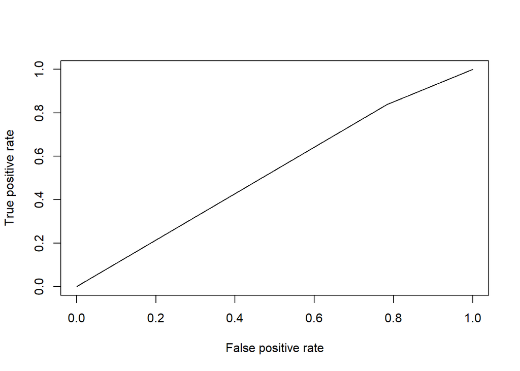

```r
predictions <- prediction(predictionsForTest, testLogAllEarnings$EPSIncrease)
modelPerfomance <- performance(predictions, measure = "tpr", x.measure = "fpr")
plot(modelPerfomance)
```

Create training and test sets for stocks in the technology sector.

```r
logTechEarnings <- tidyTechEarnings

#create a new column
logTechEarnings$EPSIncrease <- 0

#set EPS increase to 1 if EPS increased from q3 to q4
logTechEarnings$EPSIncrease[which(logTechEarnings$q4EPS > logTechEarnings$q3EPS)] <- 1

#create training and test sets
trainingLogTechEarnings <- createTrainingAndTestSets(logTechEarnings)[[1]]
testLogTechEarnings <- createTrainingAndTestSets(logTechEarnings)[[2]]

head(trainingLogTechEarnings)
```

```
##   symbol q1EPS q2EPS q3EPS q4EPS q1EPSReportDate q2EPSReportDate
## 1     MX  0.23  0.04  0.23  0.32      2018-02-06      2018-04-30
## 2   UPLD  0.26  0.28  0.18  0.21      2018-03-08      2018-05-09
## 3   FNJN  0.22  0.98  0.24 -0.24      2018-03-14      2018-05-09
## 4   PLUS  0.97  0.89  1.25  1.53      2018-02-07      2018-05-24
## 5   CREE -0.09 -0.07  0.04  0.09      2018-01-23      2018-04-24
## 6   XGTI -0.79 -0.09 -0.15 -0.13      2018-04-02      2018-05-15
##   q3EPSReportDate q4EPSReportDate EPSIncrease
## 1      2018-07-30      2018-10-30           1
## 2      2018-08-08      2018-11-08           1
## 3      2018-08-02      2018-11-13           0
## 4      2018-08-08      2018-11-07           1
## 5      2018-08-14      2018-10-16           1
## 6      2018-08-14      2018-11-14           1
```

```r
head(testLogTechEarnings)
```

```
##   symbol q1EPS q2EPS q3EPS q4EPS q1EPSReportDate q2EPSReportDate
## 1   ACIW  0.64 -0.17 -0.13  0.22      2018-02-22      2018-05-10
## 2   ACLS  0.47  0.41  0.43  0.22      2018-02-06      2018-05-02
## 3    ACN  1.79  1.58  1.79  1.58      2017-12-21      2018-03-22
## 4   ADSK -0.36 -0.19 -0.06  0.01      2018-03-06      2018-05-24
## 5   AEYE -0.50 -0.25 -0.17 -0.19      2018-04-02      2018-05-15
## 6   AIRG  0.06 -0.12 -0.34  0.04      2018-02-15      2018-05-03
##   q3EPSReportDate q4EPSReportDate EPSIncrease
## 1      2018-08-02      2018-11-08           1
## 2      2018-08-02      2018-11-01           0
## 3      2018-06-28      2018-09-27           0
## 4      2018-08-23      2018-11-20           1
## 5      2018-08-14      2018-11-14           0
## 6      2018-08-09      2018-11-01           1
```

Create a logistic model using the training data for technology stocks only.

```r
logTechModel <-  glm(EPSIncrease ~ q1EPS + q2EPS + q3EPS, family = "binomial", data = trainingLogTechEarnings)
summary(logTechModel)
```

```
##
## Call:
## glm(formula = EPSIncrease ~ q1EPS + q2EPS + q3EPS, family = "binomial",
##     data = trainingLogTechEarnings)
##
## Deviance Residuals:
##     Min       1Q   Median       3Q      Max
## -2.5958  -1.2975   0.8885   1.0226   1.7699
##
## Coefficients:
##             Estimate Std. Error z value Pr(>|z|)
## (Intercept)   0.4090     0.1162   3.520 0.000431 ***
## q1EPS         1.3037     0.3976   3.279 0.001042 **
## q2EPS         0.2204     0.4370   0.504 0.614038
## q3EPS        -1.6270     0.4890  -3.327 0.000877 ***
## ---
## Signif. codes:  0 '***' 0.001 '**' 0.01 '*' 0.05 '.' 0.1 ' ' 1
##
## (Dispersion parameter for binomial family taken to be 1)
##
##     Null deviance: 545.04  on 401  degrees of freedom
## Residual deviance: 527.02  on 398  degrees of freedom
## AIC: 535.02
##
## Number of Fisher Scoring iterations: 4
```

```r
predictionsForTestTech <- predict(logTechModel, newdata = testLogTechEarnings, type = "response")
predictionsForTestTech <- ifelse(predictionsForTestTech > .5, 1, 0)
modelAccuracyTech <- mean(predictionsForTestTech == testLogTechEarnings$EPSIncrease)
print(paste("The Model was accurate", paste(round(100*modelAccuracyTech, 2), "%", sep=""), " percent of the time."))
```

```
## [1] "The Model was accurate 57.23%  percent of the time."
```

Reshape df to build holt-winters model.

```r
holtEarnings <- data.frame(Symbol = character(), EPS = numeric(), ReportDate = character(), Quarter = numeric())
for(index in 1:nrow(allEarnings)) {
  holtEarnings <- rbind(holtEarnings, data.frame(Symbol = allEarnings[index, "symbol"], EPS = allEarnings[index, "q1EPS"], ReportDate =  allEarnings[index, "q1EPSReportDate"], Quarter = 1))
  holtEarnings <- rbind(holtEarnings, data.frame(Symbol = allEarnings[index, "symbol"], EPS = allEarnings[index, "q2EPS"], ReportDate = allEarnings[index, "q2EPSReportDate"], Quarter = 2))
  holtEarnings <- rbind(holtEarnings, data.frame(Symbol = allEarnings[index, "symbol"], EPS = allEarnings[index, "q3EPS"], ReportDate = allEarnings[index, "q3EPSReportDate"], Quarter = 3))
  holtEarnings <- rbind(holtEarnings, data.frame(Symbol = allEarnings[index, "symbol"], EPS = allEarnings[index, "q4EPS"], ReportDate = allEarnings[index, "q4EPSReportDate"], Quarter = 4))
}
head(holtEarnings)
```

```
##   Symbol   EPS ReportDate Quarter
## 1   AAPL  3.89 2018-02-01       1
## 2   AAPL  2.73 2018-05-01       2
## 3   AAPL  2.34 2018-07-31       3
## 4   AAPL  2.91 2018-11-01       4
## 5   ACIA  0.12 2018-02-22       1
## 6   ACIA -0.03 2018-05-03       2
```

Create a holt winters model and forecast future EPS. This projection seems accurate because on average comapny’s will increase with time as inflation increases and GDP grows.

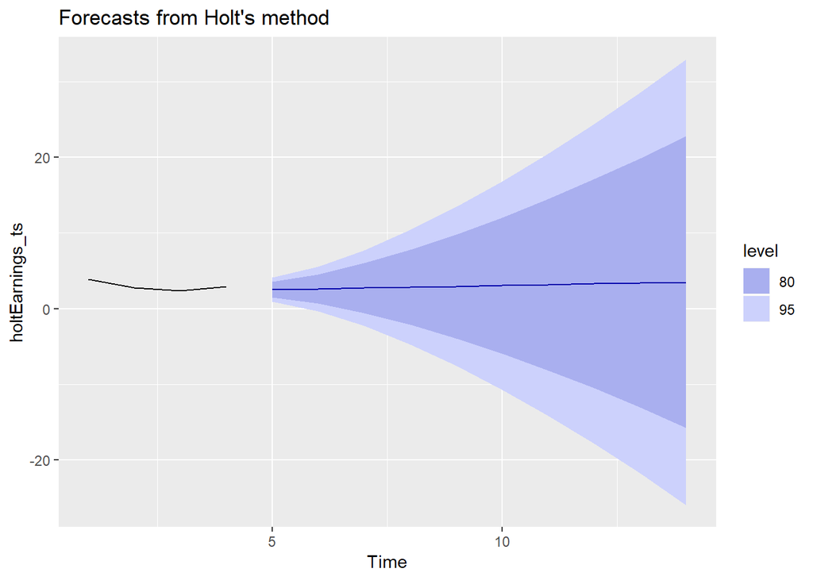

```r
holtEarnings_ts <- ts(data = holtEarnings$EPS, start= 1, end = 4)
smooth <- holt(holtEarnings_ts)
autoplot(smooth)
```

Pull the financial information from the API and create a dataframe representing it.

```r
makeFinancialsDf <- function(Symbols) {
  url <- paste("https://api.iextrading.com/1.0/stock/",
               Symbols[1], "/financials?period=quarter", sep = "")
  financialdf <- as.data.frame(fromJSON(content(GET(url), "text"))[["financials"]])
  financialdf$symbol <- Symbols[1]
  financialdf$Quarter <- 1
  financialdf[2, 'Quarter'] <- 2
  financialdf[3, 'Quarter'] <- 3
  financialdf[4, 'Quarter'] <- 4
  for(symbol in Symbols[2:length(Symbols)]) {
    url <- paste("https://api.iextrading.com/1.0/stock/",
               symbol, "/financials?period=quarter", sep = "")
    df <- as.data.frame(fromJSON(content(GET(url), "text"))[["financials"]])
    if(nrow(df > 0)) {
      df$symbol <- symbol
    df$Quarter <- 1
    df[2, 'Quarter'] <- 2
    df[3, 'Quarter'] <- 3
    df[4, 'Quarter'] <- 4
    financialdf <- rbind(financialdf, df)
    }
  }
  return(financialdf)
}

techFinancials <- makeFinancialsDf(techSymbols$symbol)
```

Observe the missing values in the data frame.

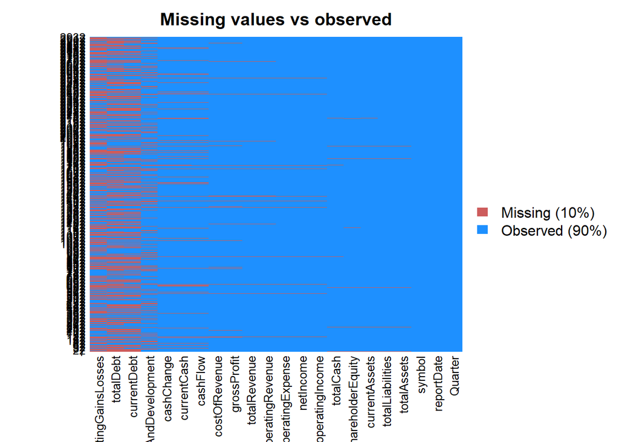

```r
missmap(techFinancials, main = "Missing values vs observed")
```

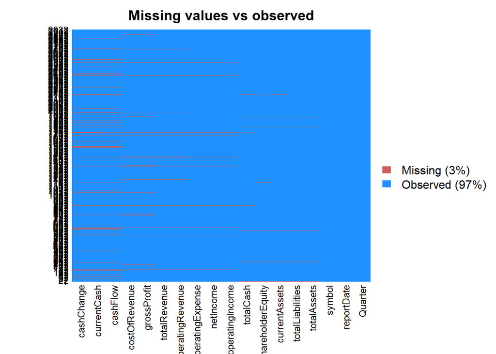

```r
tidyTechFinancials <- techFinancials
tidyTechFinancials$researchAndDevelopment <- NULL
tidyTechFinancials$currentDebt <- NULL
tidyTechFinancials$totalDebt <- NULL
tidyTechFinancials$operatingGainsLosses <- NULL
missmap(tidyTechFinancials, main = "Missing values vs observed")
```

Remove rows representing stocks that have NA values. If any stock ticker has an NA in one of its four rows, delete all rows related to it because the stock loses its signifigance to my analysis if it is not accopanied by its accompanying quarter info.

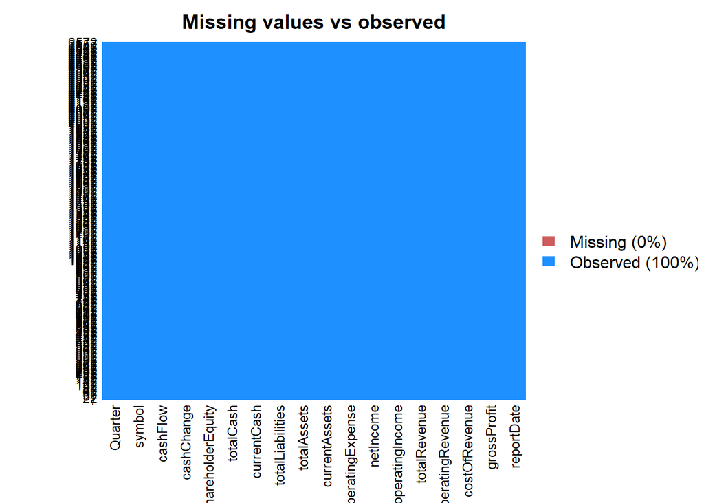

```r
noRevenueSymbols <- tidyTechFinancials$symbol[is.na(tidyTechFinancials$totalRevenue)]
noRevenueSymbols <- which(tidyTechFinancials$symbol %in% noRevenueSymbols)
tidyTechFinancials <- tidyTechFinancials[-noRevenueSymbols,]

noCashSymbols <- tidyTechFinancials$symbol[is.na(tidyTechFinancials$cashFlow)]
noCashSymbols <- which(tidyTechFinancials$symbol %in% noCashSymbols)
tidyTechFinancials <- tidyTechFinancials[-noCashSymbols,]

noCashChangeSymbols <- tidyTechFinancials$symbol[is.na(tidyTechFinancials$cashChange)]
noCashChangeSymbols <- which(tidyTechFinancials$symbol %in% noCashChangeSymbols)
tidyTechFinancials <- tidyTechFinancials[-noCashChangeSymbols,]

noAssetsSymbols <- tidyTechFinancials$symbol[is.na(tidyTechFinancials$totalAssets)]
noAssetsSymbols <- which(tidyTechFinancials$symbol %in% noAssetsSymbols)
tidyTechFinancials <- tidyTechFinancials[-noAssetsSymbols,]

noProfitsSymbols <- tidyTechFinancials$symbol[is.na(tidyTechFinancials$grossProfit)]
noProfitsSymbols <- which(tidyTechFinancials$symbol %in% noProfitsSymbols)
tidyTechFinancials <- tidyTechFinancials[-noProfitsSymbols,]

noSharesSymbols <- tidyTechFinancials$symbol[is.na(tidyTechFinancials$shareholderEquity)]
noSharesSymbols <- which(tidyTechFinancials$symbol %in% noSharesSymbols)
tidyTechFinancials <- tidyTechFinancials[-noSharesSymbols,]

noTotalCashChangeSymbols <- tidyTechFinancials$symbol[is.na(tidyTechFinancials$totalCash)]
noTotalCashChangeSymbols <- which(tidyTechFinancials$symbol %in% noTotalCashChangeSymbols)
tidyTechFinancials <- tidyTechFinancials[-noTotalCashChangeSymbols,]

missmap(tidyTechFinancials, main = "Missing values vs observed")
```

Confirm there are no NA values left in the df.

```r
sapply(tidyTechFinancials, function(x) sum(is.na(x)))
```

```
##        reportDate       grossProfit     costOfRevenue  operatingRevenue
##                 0                 0                 0                 0
##      totalRevenue   operatingIncome         netIncome  operatingExpense
##                 0                 0                 0                 0
##     currentAssets       totalAssets  totalLiabilities       currentCash
##                 0                 0                 0                 0
##         totalCash shareholderEquity        cashChange          cashFlow
##                 0                 0                 0                 0
##            symbol           Quarter
##                 0                 0
```

Create a csv representing tech financials and write a table to the stock data base storing it.

```r
write.csv(tidyTechFinancials, "techFinancial_df.csv")
dbfill2 <- dbWriteTable(Stock_db, "techFinancials_table", read.csv("techFinancial_df.csv"), overwrite = TRUE, row.names = FALSE, header = TRUE)
```

Check that the table was stored correctly.

```r
techFinancials_df <- dbGetQuery(Stock_db, "SELECT * FROM techFinancials_table")
head(techFinancials_df)
```

```
##   X reportDate grossProfit costOfRevenue operatingRevenue totalRevenue
## 1 1 2018-09-30  1.7537e+07    3.8849e+07       5.6126e+07   5.6386e+07
## 2 2 2018-06-30  3.3863e+07    5.3959e+07       8.7822e+07   8.7822e+07
## 3 3 2018-03-31  2.5836e+07    3.9403e+07       6.5239e+07   6.5239e+07
## 4 4 2017-12-31  3.2154e+07    4.7701e+07       8.1061e+07   7.9855e+07
## 5 5 2018-09-30  2.4084e+10    3.8816e+10       6.2900e+10   6.2900e+10
## 6 6 2018-06-30  2.0421e+10    3.2844e+10       5.3265e+10   5.3265e+10
##   operatingIncome   netIncome operatingExpense currentAssets totalAssets
## 1        -9402000    -3732000         26939000   2.15170e+08 4.81085e+08
## 2         8943000     8034000         24920000   2.30588e+08 4.72204e+08
## 3         2170000     2120000         23666000   2.41825e+08 4.75617e+08
## 4        10204000     5716000         21950000   2.29697e+08 4.52984e+08
## 5     16118000000 14125000000       7966000000   1.31339e+11 3.65725e+11
## 6     12612000000 11519000000       7809000000   1.15761e+11 3.49197e+11
##   totalLiabilities currentCash  totalCash shareholderEquity  cashChange
## 1      1.45600e+08  5.8075e+07 6.2402e+07       3.35485e+08 -1.9627e+07
## 2      1.29573e+08  7.7943e+07 7.6190e+07       3.42631e+08 -6.1290e+06
## 3      1.32323e+08  8.3299e+07 8.2251e+07       3.43294e+08 -1.7080e+06
## 4      1.19708e+08  8.3948e+07 8.2972e+07       3.33276e+08  1.2123e+07
## 5      2.58578e+11  2.5913e+10 6.6301e+10       1.07147e+11 -6.0580e+09
## 6      2.34248e+11  3.1971e+10 7.0970e+10       1.14949e+11 -1.3088e+10
##      cashFlow symbol Quarter
## 1     7546000   AAOI       1
## 2    22143000   AAOI       2
## 3    -4064000   AAOI       3
## 4    26786000   AAOI       4
## 5 19523000000   AAPL       1
## 6 14488000000   AAPL       2
```

Get the total Revenue for each stock in the most recent quarter

```r
revenues <- dbGetQuery(Stock_db, "SELECT symbol, totalRevenue FROM techFinancials_table WHERE Quarter = 4")
revenues <- revenues[!is.na(revenues$totalRevenue),]
head(revenues)
```

```
##   symbol totalRevenue
## 1   AAOI     79855000
## 2   AAPL  88293000000
## 3   ABIL       197000
## 4   ACIA     86603000
## 5   ACIW    326395000
## 6   ACMR     17192000
```

Find the outliers in the revenue set. It makes sense that the outliers are very high revenue totals because extra large companies make up a dispropiante percentage of gdp.

```r
totalRevenueOutliers <- findOutliers(revenues$totalRevenue)
print(paste("Total Revenue Outliers:", paste(totalRevenueOutliers, collapse = ",")))
```

```
## [1] "Total Revenue Outliers: 8.8293e+10,3.2323e+10,3.2323e+10,2.2543e+10,1.7053e+10,2.8918e+10,23716813375"
```

Creates a histogram representing the frequency of revenue bins. This shows that most companies have smaller revenues

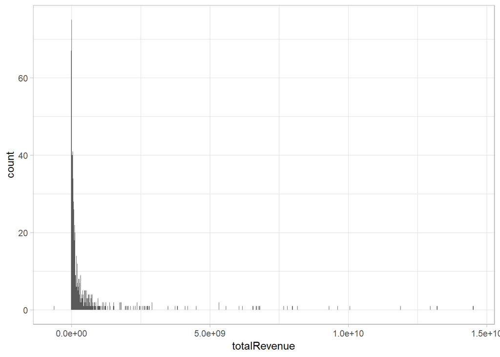

```r
revenuesNoOutliers <- revenues[-which(revenues$totalRevenue %in% totalRevenueOutliers),]
ggplot(data = revenuesNoOutliers, mapping = aes(x = totalRevenue)) +
  geom_histogram(bins=1000) + theme_light()
```

Create a new table for revenue to make the filtering process easier for the next queries.

```r
dbFill3 <- dbWriteTable(Stock_db, "totalRevenue_table", revenuesNoOutliers, overwrite =TRUE)
```

Create bins representing more infromative break points for companie’s revenue.

```r
under1million <- dbGetQuery(Stock_db, "SELECT Count(*) FROM totalRevenue_table WHERE totalRevenue < 1000000")
under10million <- dbGetQuery(Stock_db, "SELECT Count(*) FROM totalRevenue_table WHERE totalRevenue < 10000000 AND totalRevenue > 1000000")
under50million <- dbGetQuery(Stock_db, "SELECT Count(*) FROM totalRevenue_table WHERE totalRevenue < 50000000 AND totalRevenue > 10000000")
under200million <- dbGetQuery(Stock_db, "SELECT Count(*) FROM totalRevenue_table WHERE totalRevenue < 200000000 AND totalRevenue > 50000000")
under500million <- dbGetQuery(Stock_db, "SELECT Count(*) FROM totalRevenue_table WHERE totalRevenue < 500000000 AND totalRevenue >200000000")
under750million <- dbGetQuery(Stock_db, "SELECT Count(*) FROM totalRevenue_table WHERE totalRevenue < 750000000 AND totalRevenue > 500000000")
under1.25billion <- dbGetQuery(Stock_db, "SELECT Count(*) FROM totalRevenue_table WHERE totalRevenue < 1250000000 AND totalRevenue > 750000000")
under2billion <- dbGetQuery(Stock_db, "SELECT Count(*) FROM totalRevenue_table WHERE totalRevenue < 2000000000 AND totalRevenue > 1250000000")
over2billion <- dbGetQuery(Stock_db, "SELECT Count(*) FROM totalRevenue_table WHERE totalRevenue > 2000000000")
revenueBins <- rbind(under1million, under10million, under50million, under200million, under500million, under750million, under1.25billion, under2billion, over2billion)
names(revenueBins) <- "Count"
```

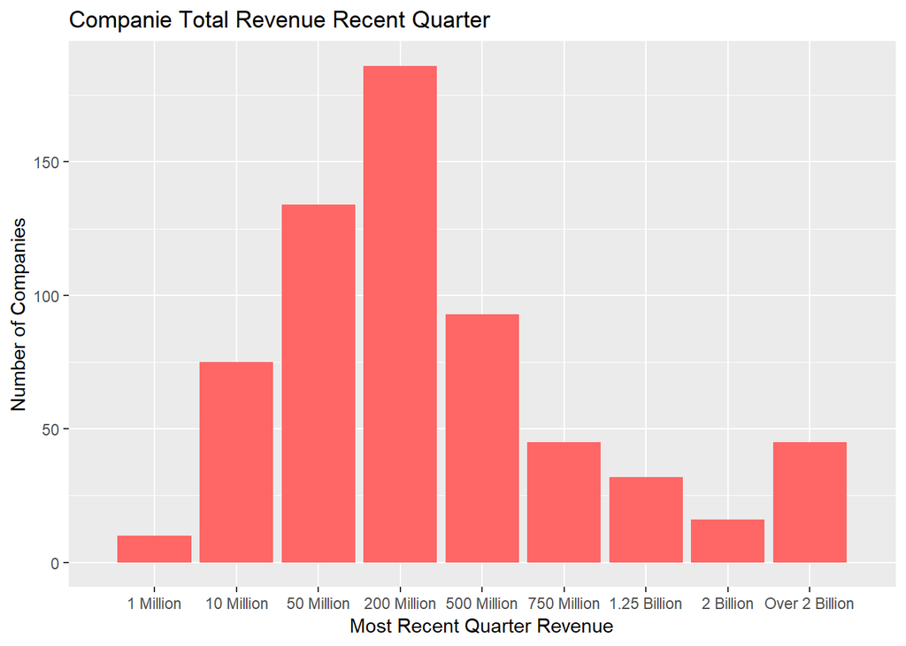

```r
ggplot(revenueBins,aes(seq_along(revenueBins$Count),revenueBins$Count)) +
  geom_bar(stat="identity", fill = "#FF6666") +
  xlab("Most Recent Quarter Revenue") +
  ylab("Number of Companies") +
  scale_x_discrete(limits=c("1 Million", "10 Million", "50 Million" , "200 Million" , "500 Million" , "750 Million" , "1.25 Billion", "2 Billion", "Over 2 Billion")) +
  ggtitle("Companie Total Revenue Recent Quarter")
```

I created a web scraper which iterates over my earnings df. It extracts from the df the symbol (which it inputs as the hashtag), the report date for q3 and the report date for q4. These values are input into text fields of the twiter advanced search page and then my scraper hits enter to search. It then is sent to a webpage which shows the top tweets related to that hashtag during the desired period. One issue with this web scraper is that if company is tweeted about more than 20 times, it can only take into account the twenty tweets on the webpage. I will handle this issue later in my analysis.

```r
#bug with zeros in day digits
removeZero <- function(string) {
  end <- substring(string, 9, 10)
  string <- substring(string, 1, 8)
  end <- str_replace(end, "0", "")
  return(paste(string, end, sep = ""))
}

getCountOfTweets <- function(url) {
  #Reading the HTML code from the website
  webpage <- read_html(url)

  #Using CSS selectors to scrap the rankings section
  tweet_data_html <- html_nodes(webpage,'.js-original-tweet')

  #Converting the ranking data to character vector
  tweets <- html_text(tweet_data_html)

  return(length(tweets))
}

rD <- rsDriver() # runs a chrome browser, wait for necessary files to download
```

[output not shown]

[output not shown]

[output not shown]

[output not shown]

[output not shown]

[output not shown]

[output not shown]

[output not shown]

[output not shown]

[output not shown]

[output not shown]

[output not shown]

[output not shown]

[output not shown]

[output not shown]

[output not shown]

[output not shown]

[output not shown]

[output not shown]

[output cut: 47 more lines]

[output not shown]

```r
remDr <- rD$client
remDr$open()
```

[output not shown]

[output cut: 47 more lines]

[output not shown]

```r
getTwitterVolumes <- function(df){
  df$tweetVolume <- 0
  for(index in 1:nrow(df)) {
    #load twitter page
    remDr$navigate("https://twitter.com/search-advanced")

    #add "price" to text search box
    priceBox <- remDr$findElement(using = 'css selector', "fieldset:nth-child(1) .txt:nth-child(3) input")
    priceBox$sendKeysToElement(list("price"))

    #add ticker symbol to hastag box
    hashtagBox <- remDr$findElement(using = 'css selector', ".txt:nth-child(6) input")
    hashtagBox$sendKeysToElement(list(df[index, 'symbol']))

    #add q3reportdate to since box
    sinceBox <- remDr$findElement(using = 'css selector', "#since")
    sinceBox$sendKeysToElement(list(removeZero(df[index, 'q3EPSReportDate'])))

    #add q4reportdate to until box
    untilBox <- remDr$findElement(using = 'css selector', "#until")
    untilBox$sendKeysToElement(list(removeZero(df[index, 'q4EPSReportDate'])))

    #hit enter to search the inputs
    hitEnter <- remDr$findElement(using = 'css selector', "fieldset:nth-child(1) legend+ .txt input")
    hitEnter$sendKeysToElement(list("\uE007", "\uE007"))

    #add tweet volume to df
    df[index, 'tweetVolume'] <- getCountOfTweets(remDr$getCurrentUrl()[[1]])
  }
  return(df)
}

tidyTechEarningsTweets <- getTwitterVolumes(tidyTechEarnings)
row.names(tidyTechEarningsTweets) <- c(1:nrow(tidyTechEarningsTweets))
head(tidyTechEarningsTweets)
```

```
##   symbol q1EPS q2EPS q3EPS q4EPS q1EPSReportDate q2EPSReportDate
## 1   AAPL  3.89  2.73  2.34  2.91      2018-02-01      2018-05-01
## 2   ACIA  0.12 -0.03 -0.08  0.23      2018-02-22      2018-05-03
## 3   ACIW  0.64 -0.17 -0.13  0.22      2018-02-22      2018-05-10
## 4   ACLS  0.47  0.41  0.43  0.22      2018-02-06      2018-05-02
## 5   ACMR  0.23 -0.04  0.19  0.21      2018-03-05      2018-05-08
## 6    ACN  1.79  1.58  1.79  1.58      2017-12-21      2018-03-22
##   q3EPSReportDate q4EPSReportDate tweetVolume
## 1      2018-07-31      2018-11-01          20
## 2      2018-08-02      2018-11-01           1
## 3      2018-08-02      2018-11-08           0
## 4      2018-08-02      2018-11-01           5
## 5      2018-08-07      2018-11-07           0
## 6      2018-06-28      2018-09-27           0
```

Clean the new data and to data frame which integrates tweets and earnings data.

```r
tidyTechFinancialsTweets <- tidyTechFinancials
tidyTechFinancialsTweets$tweetVolume <- -1
for(index in 1:nrow(tidyTechEarningsTweets)) {
  tweetVolume <- tidyTechEarningsTweets[index, 'tweetVolume']
  if(tidyTechEarningsTweets[index, 'symbol'] %in% tidyTechFinancialsTweets$symbol) {
    earningsSymbol <- tidyTechEarningsTweets[index, 'symbol']

    #get 4th quarter index of the symbol
    financialIndex <- which(tidyTechFinancialsTweets$symbol == earningsSymbol)[4]

    #add tweet voume to tech financials
    tidyTechFinancialsTweets[financialIndex, 'tweetVolume'] <-tweetVolume
  }
}

head(tidyTechFinancialsTweets)
```

```
##   reportDate grossProfit costOfRevenue operatingRevenue totalRevenue
## 1 2018-09-30  1.7537e+07    3.8849e+07       5.6126e+07   5.6386e+07
## 2 2018-06-30  3.3863e+07    5.3959e+07       8.7822e+07   8.7822e+07
## 3 2018-03-31  2.5836e+07    3.9403e+07       6.5239e+07   6.5239e+07
## 4 2017-12-31  3.2154e+07    4.7701e+07       8.1061e+07   7.9855e+07
## 5 2018-09-30  2.4084e+10    3.8816e+10       6.2900e+10   6.2900e+10
## 6 2018-06-30  2.0421e+10    3.2844e+10       5.3265e+10   5.3265e+10
##   operatingIncome   netIncome operatingExpense currentAssets totalAssets
## 1        -9402000    -3732000         26939000   2.15170e+08 4.81085e+08
## 2         8943000     8034000         24920000   2.30588e+08 4.72204e+08
## 3         2170000     2120000         23666000   2.41825e+08 4.75617e+08
## 4        10204000     5716000         21950000   2.29697e+08 4.52984e+08
## 5     16118000000 14125000000       7966000000   1.31339e+11 3.65725e+11
## 6     12612000000 11519000000       7809000000   1.15761e+11 3.49197e+11
##   totalLiabilities currentCash  totalCash shareholderEquity  cashChange
## 1      1.45600e+08  5.8075e+07 6.2402e+07       3.35485e+08 -1.9627e+07
## 2      1.29573e+08  7.7943e+07 7.6190e+07       3.42631e+08 -6.1290e+06
## 3      1.32323e+08  8.3299e+07 8.2251e+07       3.43294e+08 -1.7080e+06
## 4      1.19708e+08  8.3948e+07 8.2972e+07       3.33276e+08  1.2123e+07
## 5      2.58578e+11  2.5913e+10 6.6301e+10       1.07147e+11 -6.0580e+09
## 6      2.34248e+11  3.1971e+10 7.0970e+10       1.14949e+11 -1.3088e+10
##      cashFlow symbol Quarter tweetVolume
## 1     7546000   AAOI       1          -1
## 2    22143000   AAOI       2          -1
## 3    -4064000   AAOI       3          -1
## 4    26786000   AAOI       4          -1
## 5 19523000000   AAPL       1          -1
## 6 14488000000   AAPL       2          -1
```

Create a new data frame with only the most recent quarter and stocks that have tweet information. There were discrepencies bewteen stock that were in earnings and stocks within financials so they must be combined.

```r
fourthQuarterTweetsAndFinancials_df <- tidyTechFinancialsTweets[which(tidyTechFinancialsTweets$Quarter == 4),]
fourthQuarterTweetsAndFinancials_df <- fourthQuarterTweetsAndFinancials_df[which(fourthQuarterTweetsAndFinancials_df$tweetVolume > -1),]
head(fourthQuarterTweetsAndFinancials_df)
```

```
##    reportDate grossProfit costOfRevenue operatingRevenue totalRevenue
## 8  2017-12-31 33912000000   54381000000      88293000000  88293000000
## 16 2017-12-31    40016000      46587000         86603000     86603000
## 20 2017-12-31   210402000     115993000        326395000    326395000
## 28 2017-12-31     9173000       8019000         17192000     17192000
## 32 2017-11-30  3052260000    7002233000       9523222000  10054493000
## 36 2017-11-30  1735723000     270872000       2006595000   2006595000
##    operatingIncome   netIncome operatingExpense currentAssets  totalAssets
## 8      26274000000 20065000000       7638000000  143810000000 406794000000
## 16         4943000   -20364000         35073000     447247000    611250000
## 20       108037000    33164000        102365000     421821000   1861639000
## 28         3765000     3384000          5408000      62914000     67891000
## 32      1485880000  1123660000       1566380000   12303841000  22974153000
## 36       649340000   501549000       1086383000    7247813000  14535556000
##    totalLiabilities currentCash   totalCash shareholderEquity cashChange
## 8      266595000000 27491000000 77153000000      140199000000 7202000000
## 16        109200000    67495000   279428000         502050000  -46636000
## 20       1097042000    69710000    69710000         764597000    5777000
## 28         28034000    17681000    17681000          39857000      40000
## 32      13080716000  3681711000  3682393000        9102130000 -432141000
## 36       6075687000  2306072000  5819774000        8459869000  534077000
##       cashFlow symbol Quarter tweetVolume
## 8  28293000000   AAPL       4          20
## 16    20076000   ACIA       4           1
## 20    61125000   ACIW       4           0
## 28    -3440000   ACMR       4           0
## 32  1005838000    ACN       4           0
## 36   833220000   ADBE       4           0
```

```r
nrow(fourthQuarterTweetsAndFinancials_df)
```

```
## [1] 526
```

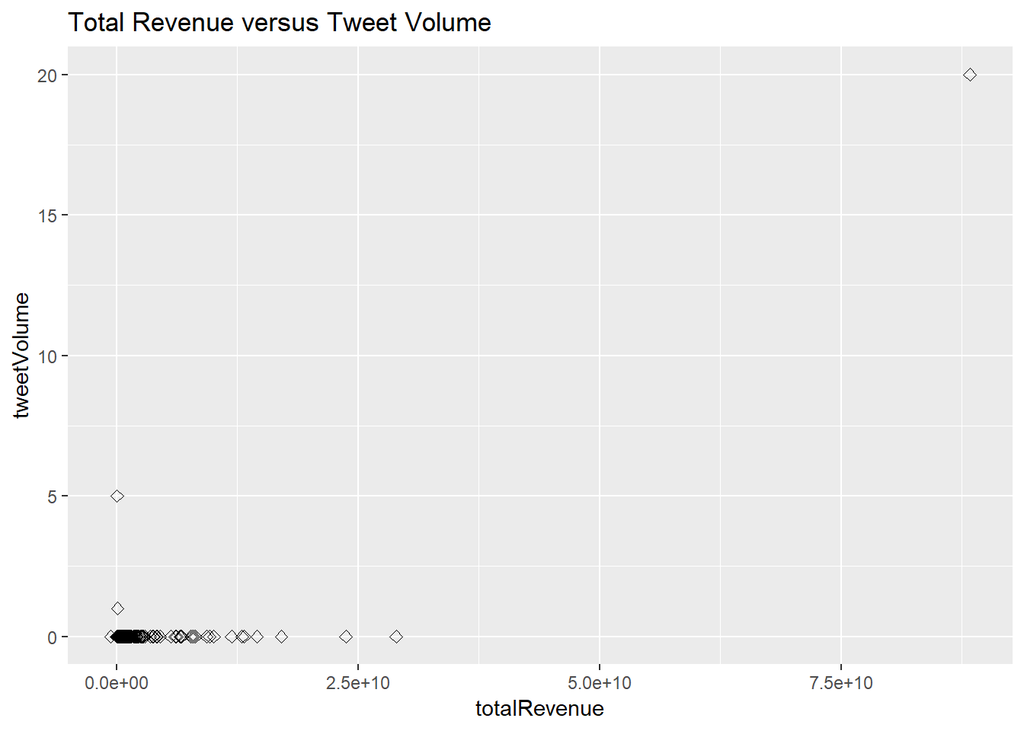

```r
ggplot(fourthQuarterTweetsAndFinancials_df, aes(x=totalRevenue, y=tweetVolume)) +
  geom_point(size=2, shape=23) +
  ggtitle("Total Revenue versus Tweet Volume")
```

Remove all tweet volumes of twenty because they are not accurate data points.

```r
fourthQuarterTweetsAndFinancials_df <- fourthQuarterTweetsAndFinancials_df[which(fourthQuarterTweetsAndFinancials_df$tweetVolume < 20),]
```

This scatter plot gives a better representation of the lack of correlation between Revenue and Tweet Volume.

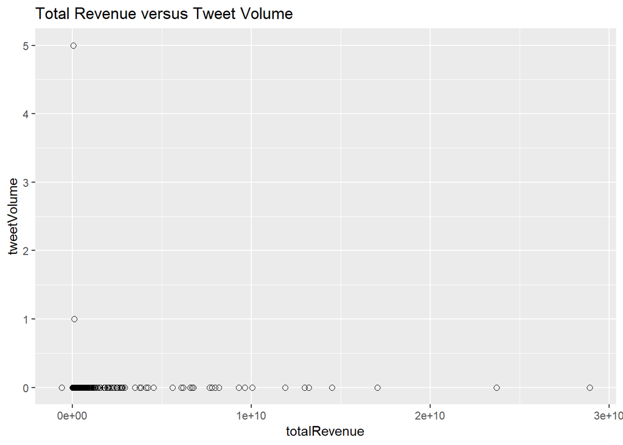

```r
ggplot(fourthQuarterTweetsAndFinancials_df, aes(x=totalRevenue, y=tweetVolume)) +
  geom_point(size=2, shape=21) +
  ggtitle("Total Revenue versus Tweet Volume")
```

```r
cor(fourthQuarterTweetsAndFinancials_df$tweetVolume, fourthQuarterTweetsAndFinancials_df$totalRevenue,  method = "pearson")
```

```
## [1] -0.0152931
```

Prepare the dataframe to create a linear regression model. Remove any variables which are unique to a stock.

```r
linearModelTechTweets <- fourthQuarterTweetsAndFinancials_df
linearModelTechTweets$symbol <- NULL
linearModelTechTweets$reportDate <- NULL
linearModelTechTweets$Quarter <- NULL
trainingLinearModelTechTweets <- createTrainingAndTestSets(linearModelTechTweets)[[1]]
testLinearModelTechTweets <- createTrainingAndTestSets(linearModelTechTweets)[[2]]
fullSet <- lm(formula = tweetVolume ~., data = trainingLinearModelTechTweets)
summary(fullSet)
```

```
##
## Call:
## lm(formula = tweetVolume ~ ., data = trainingLinearModelTechTweets)
##
## Residuals:
##     Min      1Q  Median      3Q     Max
## -0.0176 -0.0160 -0.0157 -0.0143  4.9839
##
## Coefficients:
##                     Estimate Std. Error t value Pr(>|t|)
## (Intercept)        1.611e-02  1.555e-02   1.037    0.301
## grossProfit       -4.622e-08  8.336e-07  -0.055    0.956
## costOfRevenue      1.966e-08  3.551e-07   0.055    0.956
## operatingRevenue  -8.073e-12  4.544e-10  -0.018    0.986
## totalRevenue      -1.965e-08  3.550e-07  -0.055    0.956
## operatingIncome    6.589e-08  1.189e-06   0.055    0.956
## netIncome         -1.725e-12  5.655e-11  -0.031    0.976
## operatingExpense   6.589e-08  1.189e-06   0.055    0.956
## currentAssets     -2.831e-12  2.974e-11  -0.095    0.924
## totalAssets       -1.031e-11  1.563e-10  -0.066    0.947
## totalLiabilities   1.004e-11  1.578e-10   0.064    0.949
## currentCash       -1.135e-12  1.771e-11  -0.064    0.949
## totalCash          3.706e-12  2.921e-11   0.127    0.899
## shareholderEquity  1.010e-11  1.580e-10   0.064    0.949
## cashChange        -3.491e-12  5.710e-11  -0.061    0.951
## cashFlow           1.876e-12  8.178e-11   0.023    0.982
##
## Residual standard error: 0.2664 on 351 degrees of freedom
## Multiple R-squared:  0.000499,   Adjusted R-squared:  -0.04221
## F-statistic: 0.01168 on 15 and 351 DF,  p-value: 1
```

Step through the model for optimization.

```r
optimizedModel <- step(fullSet, trainingLinearModelTechTweets, direction = "backward")
```

```
## Start:  AIC=-955.12
## tweetVolume ~ grossProfit + costOfRevenue + operatingRevenue +
##     totalRevenue + operatingIncome + netIncome + operatingExpense +
##     currentAssets + totalAssets + totalLiabilities + currentCash +
##     totalCash + shareholderEquity + cashChange + cashFlow
##
##                     Df  Sum of Sq    RSS     AIC
## - operatingRevenue   1 0.00002241 24.919 -957.12
## - cashFlow           1 0.00003737 24.919 -957.12
## - netIncome          1 0.00006607 24.919 -957.12
## - totalRevenue       1 0.00021767 24.920 -957.12
## - costOfRevenue      1 0.00021777 24.920 -957.12
## - operatingIncome    1 0.00021812 24.920 -957.12
## - operatingExpense   1 0.00021814 24.920 -957.12
## - grossProfit        1 0.00021828 24.920 -957.12
## - cashChange         1 0.00026540 24.920 -957.12
## - totalLiabilities   1 0.00028721 24.920 -957.12
## - shareholderEquity  1 0.00028990 24.920 -957.12
## - currentCash        1 0.00029185 24.920 -957.12
## - totalAssets        1 0.00030888 24.920 -957.12
## - currentAssets      1 0.00064374 24.920 -957.12
## - totalCash          1 0.00114293 24.921 -957.11
## <none>                            24.919 -955.12
##
## Step:  AIC=-957.12
## tweetVolume ~ grossProfit + costOfRevenue + totalRevenue + operatingIncome +
##     netIncome + operatingExpense + currentAssets + totalAssets +
##     totalLiabilities + currentCash + totalCash + shareholderEquity +
##     cashChange + cashFlow
##
##                     Df  Sum of Sq    RSS     AIC
## - cashFlow           1 0.00003061 24.919 -959.12
## - netIncome          1 0.00005872 24.919 -959.12
## - totalRevenue       1 0.00019983 24.920 -959.12
## - costOfRevenue      1 0.00019986 24.920 -959.12
## - operatingIncome    1 0.00020020 24.920 -959.12
## - operatingExpense   1 0.00020022 24.920 -959.12
## - grossProfit        1 0.00020035 24.920 -959.12
## - currentCash        1 0.00027120 24.920 -959.12
## - totalLiabilities   1 0.00027651 24.920 -959.12
```

[output cut: 179 more lines]

```
##
##                 Df Sum of Sq    RSS     AIC
## - totalCash      1 0.0040116 24.926 -983.03
## - currentAssets  1 0.0069743 24.929 -982.98
## <none>                       24.922 -981.09
##
## Step:  AIC=-983.03
## tweetVolume ~ currentAssets
##
##                 Df Sum of Sq    RSS     AIC
## - currentAssets  1 0.0058942 24.932 -984.94
## <none>                       24.926 -983.03
##
## Step:  AIC=-984.94
## tweetVolume ~ 1
```

```r
summary(optimizedModel)
```

```
##
## Call:
## lm(formula = tweetVolume ~ 1, data = trainingLinearModelTechTweets)
##
## Residuals:
##     Min      1Q  Median      3Q     Max
## -0.0136 -0.0136 -0.0136 -0.0136  4.9864
##
## Coefficients:
##             Estimate Std. Error t value Pr(>|t|)
## (Intercept)  0.01362    0.01362       1    0.318
##
## Residual standard error: 0.261 on 366 degrees of freedom
```

Disconnect from database.

```r
dbDisconnect(Stock_db)
```